# Laboratorio 3

Grupo 1: Jesús Guzmán, M del Carmen Carranza, Oscar Agüero, Ricardo Zamora

Fecha de entrega: 26/05/2021

# Instrucciones generales

```r
library(dplyr)
library(tidyverse)
```

Genere un R Markdown en donde se muestre el código utilizado y la salida de este.

En este ejercicio vamos a generar un dataset aleatorio de acuerdo con el modelo $Yi=m(xi)+ϵi,i=1,…,101, $

$m(x)=x+4cos(7x)$

$ϵ1,…,ϵ101 iid N(0,1)$. En las partes 1, 2 y 3 utilizaremos el mismo diseño equidistante para xi, mientras que 4 utilizaremos un diseño aleatorio.

Nota: fije una semilla para asegurar reproductibilidad de los resultados, e.g. set.seed(1).

## PREGUNTA 1

```r
set.seed(1)
mx=function(x){
  x+4*cos(7*x)
}
ei=matrix(rnorm((101*1000),0,1), nrow=101, ncol=1000)
xi=seq(from=-1, to=1, length=101)

yi=mx(xi)+ei

yv=mx(xi)
```

### Modelo Nayadara-Watson

```r
library(stats)
modelo<-matrix(NA, nrow=101, ncol=1000)
for (i in 1:1000) {
  mod=ksmooth(x=xi, y=yi[,i], bandwidth = 0.2)
  modelo[,i]<-mod$y
}
```

**Para el cálculo de los grados de libertad**

```r
n<-length(yv)
x<-xi
S<-matrix(NA, nrow = n, ncol=n)
colnames(S)<- 1:n
In<-diag(n)
h=0.2

for (j in 1:n){
  krs<-ksmooth(x=x,
               y=In[,j],
               kernel = "normal",
               bandwidth = h,
               x.points = x)
  S[,j]<-krs$y
}

sum(diag(S))
```

```
## [1] 11.33399
```

### Modelo Regresión local polinomial

Ajustar el span

```r
#Para seleccionar el span. Trabajamos únicamente con una configuración (yi[,1])

h=c(0.1,0.2,0.3,0.4,.5,.6,.7,.8,.9,1)
df<-rep(0, length(h))
for (i in 1:length(h)){
  mod<-loess(yi[,1]~xi, span=h[i])
  df[i]<-mod$enp
}
df
```

```
##  [1] 28.857612 14.745924  9.941612  7.645838  6.260512  5.273548  4.614592
##  [8]  4.132075  3.745832  3.450121
```

El valor más cercano a 11.33 se da entre el span igual a 0.2 y 0.3., estando más cercano a 0.3. Por ende, utilizaremos 0.258

```r
modelo1<-matrix(NA, nrow=101, ncol=1000)
for (i in 1:1000) {
  mod1<-loess(yi[,i]~xi, span = 0.258)
  modelo1[,i]<-mod1$fitted
}
```

### Modelo de splines de suavizado

Se usan los grados de libertad igual a 11.33

```r
modelo2<-matrix(NA, nrow=101, ncol=1000)
for (i in 1:1000) {
  mod2<-smooth.spline(yi[,i]~xi, , df=11.33)
  modelo2[,i]<-(predict(mod2, xi)$y)
}
```

### Pregunta B

Para cada punto xi, calcule

1. el sesgo empírico de m(xi) (promedio a lo largo de todas las simulaciones menos el valor verdadero m(x)),

**Modelo Nayadara-Watson**

```r
SE1.MAT<-yv-modelo
SE1<-rep(NA, 101)
for (i in 1:101){
  SE1[i]<-mean(SE1.MAT[i,])
}
```

**Modelo de regresión local polinomial**

```r
SE2.MAT<-yv-modelo1
SE2<-rep(NA, 101)
for (i in 1:101){
  SE2[i]<-mean(SE2.MAT[i,])
}
SE2
```

```
##   [1] -0.2316340280 -0.1285867768 -0.0353086708  0.0466675675  0.1148423508
##   [6]  0.1627346870  0.1850080674  0.1884854958  0.1757103509  0.1371769745
##  [11]  0.1017543611  0.0784610232  0.0299566857  0.0033950264  0.0308224438
##  [16]  0.0535322607  0.0133106503 -0.0150017349  0.0115225456 -0.0130922380
##  [21] -0.0426788202 -0.0199435720 -0.0349976777 -0.0596301159 -0.0436988039
##  [26] -0.0460328470 -0.0669324788 -0.0693877741 -0.0583859878 -0.0404412970
##  [31] -0.0410249141 -0.0512572768 -0.0283479520 -0.0195133073 -0.0437978894
##  [36] -0.0179968780  0.0012846598 -0.0276285590 -0.0002817624  0.0256531627
##  [41] -0.0041708767  0.0194409579  0.0486283270  0.0246146548  0.0409138566
##  [46]  0.0655064106  0.0467541545  0.0502564946  0.0667630239  0.0584402210
##  [51]  0.0500832234  0.0601353958  0.0762267484  0.0791998577  0.0513692791
##  [56]  0.0417949355  0.0601847081  0.0317462169  0.0117204078  0.0373801125
##  [61]  0.0082438113 -0.0180735707  0.0104786112 -0.0145421881 -0.0414258887
##  [66] -0.0124265065 -0.0274919623 -0.0497564015 -0.0248385677 -0.0278199295
##  [71] -0.0486394035 -0.0440463312 -0.0413473836 -0.0554658029 -0.0674064703
##  [76] -0.0558616859 -0.0513292106 -0.0724182773 -0.0821117826 -0.0446225903
##  [81] -0.0257972148 -0.0495496029 -0.0185703177  0.0105970316 -0.0127436812
##  [86]  0.0169660013  0.0466796426  0.0201927243  0.0387494922  0.0875955735
##  [91]  0.1100284070  0.1456644726  0.1854580038  0.1993223079  0.1972535812
##  [96]  0.1767098261  0.1306142713  0.0644112409 -0.0152909062 -0.1060153958
## [101] -0.2063469608
```

**Modelo de splines de suavizado**

```r
yv-modelo2[,1]
```

```
##   [1] -0.630759299 -0.396007004 -0.218290944 -0.089851582 -0.001431800
##   [6]  0.053002175  0.080558759  0.089347351  0.086092945  0.076998735
##  [11]  0.063934737  0.046232886  0.021149473 -0.020290291 -0.075978709
##  [16] -0.139596774 -0.203076864 -0.257546647 -0.294450698 -0.310010653
##  [21] -0.302466879 -0.273895487 -0.233400685 -0.191170354 -0.153276914
##  [26] -0.124209729 -0.104162151 -0.094869251 -0.097455940 -0.104533510
##  [31] -0.107749760 -0.101705327 -0.087984121 -0.071493368 -0.059412579
##  [36] -0.055358268 -0.060768705 -0.070598611 -0.078065941 -0.076608262
##  [41] -0.066753741 -0.050893813 -0.031539019 -0.011445612  0.006454890
##  [46]  0.017374403  0.018617406  0.014385550  0.006865725 -0.002600254
##  [51] -0.015112814 -0.032223740 -0.057276165 -0.090546837 -0.128365993
##  [56] -0.161629997 -0.191392181 -0.220653717 -0.250576244 -0.279514847
##  [61] -0.300023419 -0.309888358 -0.309871132 -0.305823939 -0.303723994
##  [66] -0.308127424 -0.318390982 -0.330679997 -0.333211034 -0.317506296
##  [71] -0.279754985 -0.226110383 -0.164955057 -0.104980230 -0.053094587
##  [76] -0.014739911  0.011641245  0.027659731  0.033630689  0.029515972
##  [81]  0.014829819 -0.009298941 -0.038671568 -0.069959008 -0.103251477
##  [86] -0.133621539 -0.155668917 -0.168428508 -0.171763178 -0.165503237
##  [91] -0.149126807 -0.120263943 -0.073661366 -0.009504835  0.068853857
##  [96]  0.148894759  0.214745759  0.245154632  0.225892173  0.147665760
## [101]  0.008737689
```

```r
SE3.MAT<-yv-modelo2
SE3<-rep(NA, 101)
for (i in 1:101){
  SE3[i]<-mean(SE3.MAT[i,])
}
SE3
```

```
##   [1] -0.762022915 -0.450315522 -0.198787683 -0.004645149  0.137227708
##   [6]  0.233949590  0.292913387  0.321896706  0.327075231  0.314758611
##  [11]  0.289879994  0.256008954  0.216839937  0.174693235  0.131133022
##  [16]  0.087847983  0.045851251  0.006028655 -0.031142361 -0.065437733
##  [21] -0.096846947 -0.125129838 -0.149704282 -0.170298757 -0.186211283
##  [26] -0.197412112 -0.204133764 -0.206373059 -0.204686896 -0.198910937
##  [31] -0.189527383 -0.176859537 -0.160838071 -0.142058952 -0.120857841
##  [36] -0.097355352 -0.072070165 -0.045096128 -0.016758439  0.012401084
##  [41]  0.041563514  0.069929443  0.096886677  0.121811704  0.144367178
##  [46]  0.164036575  0.180795143  0.194358501  0.204102291  0.209992905
##  [51]  0.211602881  0.209287043  0.203392275  0.193642263  0.180411150
##  [56]  0.163786416  0.143715563  0.120699577  0.094873980  0.066798823
##  [61]  0.037309859  0.007369973 -0.021968642 -0.050036989 -0.076462637
##  [66] -0.101077471 -0.123577298 -0.144025112 -0.162234917 -0.177733626
##  [71] -0.190639350 -0.200648882 -0.207213212 -0.210392130 -0.209534119
##  [76] -0.204620367 -0.195431619 -0.181413287 -0.162608589 -0.138736184
##  [81] -0.110091888 -0.077250656 -0.040807304 -0.001568539  0.040077382
##  [86]  0.083778407  0.128983925  0.174359487  0.218572280  0.259699874
##  [91]  0.294931758  0.321553437  0.335340295  0.330996762  0.303386109
##  [96]  0.245672080  0.151128262  0.011990658 -0.179034214 -0.427420686
## [101] -0.735410557
```

2. La varianza de m^(xi)

**Modelo Nayadara-Watson**

```r
variancia1<-rep(0, 101)
for (i in 1:101){
  variancia1[i]<-var(modelo[i,])
}
```

**Modelo de regresión local polinomial**

```r
variancia2<-rep(0, 101)
for (i in 1:101){
  variancia2[i]<-var(modelo1[i,])
}
```

**Modelo de splines de suavizado**

```r
variancia3<-rep(0, 101)
for (i in 1:101){
  variancia3[i]<-var(modelo2[i,])
}
```

```r
RE1<-SE1.MAT^2
MSE1<-rep (0, 101)
for (i in 1:101){
MSE1[i]<-(sum(RE1[,i])/101)
}

RE2<-SE2.MAT^2
MSE2<-rep (0, 101)
for (i in 1:101){
MSE2[i]<-(sum(RE2[,i])/101)
}

RE3<-SE3.MAT^2
MSE3<-rep (0, 101)
for (i in 1:101){
MSE3[i]<-(sum(RE3[,i])/101)
}
```

### Pregunta C

Grafique estas tres cantidades contra xi para los estimadores.

**Modelo Nayadara-Watson**

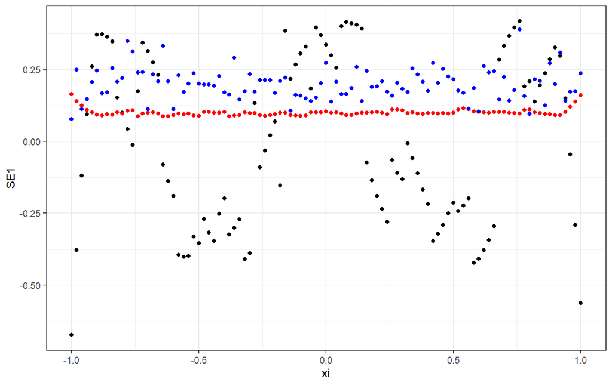

```r
library (ggplot2)
NW<-cbind(variancia1, SE1, MSE1, xi)
NW<-tibble::tibble(NW)

graf1<-ggplot (NW) + geom_point(aes(x=xi, y=SE1))+geom_point(x=xi, y=variancia1, col="red")+geom_point(x=xi, y=MSE1, col="blue")+theme_bw()
graf1
```

**Modelo de regresión local polinomial**

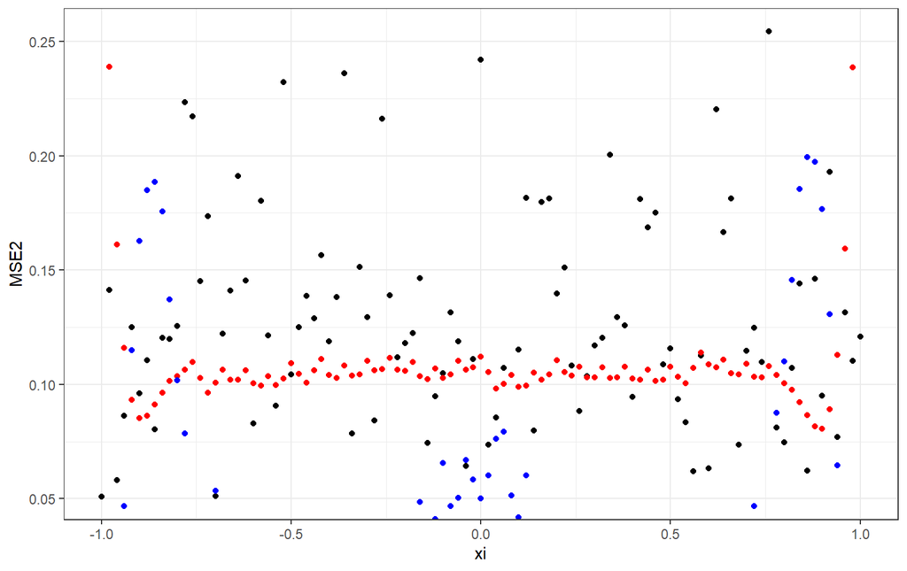

```r
RLP<-cbind(variancia2, SE2, MSE2, xi)
RLP<-tibble::tibble(RLP)

graf2<-ggplot (RLP) + geom_point(aes(x=xi, y=MSE2))+geom_point(x=xi, y=variancia2, col="red")+geom_point(x=xi, y=SE2, col="blue")+theme_bw()
graf2
```

**Modelo de splines de suavizado**

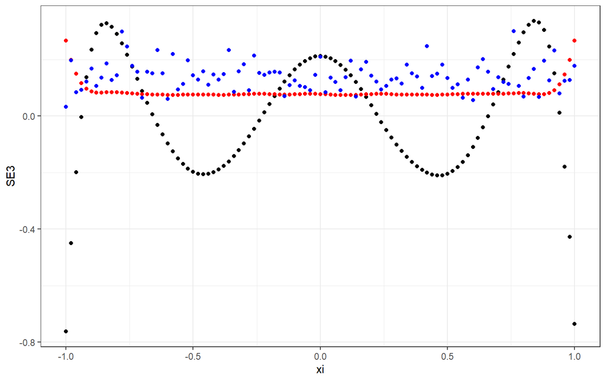

```r
MSS<-cbind(variancia3, SE3, MSE3, xi)
MSS<-tibble::tibble(MSS)

graf1<-ggplot (MSS) + geom_point(aes(x=xi, y=SE3))+geom_point(x=xi, y=variancia3, col="red")+geom_point(x=xi, y=MSE3, col="blue")+theme_bw()
graf1
```

### Pregunta D

¿Cuál es la conexión entre el sesgo y la curvatura $m^{\prime\prime}(x)$?

Si se observa el sesgo de los tres modelos, se logra visualizar como en los tres modelos el sesgo sigue la misma trayectoria que la curvatura original. En el modelo de regresión local es menos clara pues el sesgo presenta mayor dispersión, sin embargo tambien tiene un comportamiento similar.

### Pregunta E

¿Cómo se comporta el sesgo en los bordes?

En los bordes el sesgo se crece de sobremanera en negativo, y se aleja de la curvatura y del promedio de las tres mediciones. De igual manera, en el modelo polinomial este comportamiento es menos fuerte.

## PREGUNTA 2

**A.** Calcule el correspondiente estimado de error estándar para cada una de las 1000 simulaciones, los 101 $x_i$ y los tres estimadores de regresión estudiados según la fórmula:

$$\hat{\text{se}}\left(\hat{m}(x_i)\right) = \sqrt{ \hat{\mathbb{V}\text{ar}}\left(\hat{m}(x_i)\right)} = \hat{\sigma}_{\epsilon} \sqrt{\left(\mathcal{S} \mathcal{S}^{\intercal} \right)_{ii}}$$

Para estimar *manualmente* el error estándar necesitamos las correspondientes matrices de suavizado (o *hat matrices*) $\mathcal{S}$. Recuerden que las matrices $\mathcal{S}$ dependen únicamente de los puntos de diseño $x_i$ y, por ende, no deben ser calculadas para cada simulación (mas sí para cada método de regresión).

```r
library(tidyverse)
```

```r
set.seed(1)
xi=seq(from=-1, to=1, length=101)
mx=function(x){
  x+4*cos(7*x)
}

# replicando los valores pero en una lista
yi <- vector("list", 1000)

for(i in 1:1000){
  yi[[i]] <-  mx(xi) + rnorm(101, 0, 1)
}

nad_res <- yi %>%
  map(~{ksmooth(x = xi, y = .x, kernel = 'normal', bandwidth = 0.2) %>%
      pluck("y")})

pol_res <- yi %>%
  map(function(y){
      res <- loess(y ~ xi, span = 0.258)
      return(list(
        fitted = res$fitted,
        resid = res$residuals
      ))
  })

# Replico la Matriz S para no tener NA's

n <- length(xi)
x <- xi
S <- matrix(NA, nrow = n, ncol=n)
colnames(S) <- 1:n
In <- diag(n)
h <- 0.2

for (j in 1:n){
  krs<-ksmooth(x=x,
               y=In[,j],
               kernel = "normal",
               bandwidth = h,
               x.points = x)
  S[,j]<-krs$y
}


spl_res <- yi %>%
  map(function(y){
      res <- smooth.spline(xi, y, df = sum(diag(S)))
      return(list(
        fitted = res$y,
        lambda = res$lambda
      ))
  })


# Para KS
se_ks <- vector("list", length(x))
raiz_S <- sqrt(S%*%t(S))

for(j in 1:1000){
  wi <- nad_res[[j]]
  sigma_2 <- sum((wi - yi[[j]])^2)/(length(wi)-sum(diag(S)))
  se_ks[[j]] <- sqrt(sigma_2)*diag(raiz_S)

}


# Para Loess
se_ls <- vector("list", length(x))
raiz_S <- sqrt(modelo1%*%t(modelo1))

for(j in 1:1000){
  wi <- pol_res[[j]]$fitted
  sigma_2 <- sum((wi - yi[[j]])^2)/(length(wi)-sum(diag(modelo1)))
  se_ls[[j]] <- sqrt(sigma_2)*diag(raiz_S)

}

# Para Splines
se_sp <- vector("list", length(x))
raiz_S <- sqrt(modelo2%*%t(modelo2))

for(j in 1:1000){
  wi <- spl_res[[j]]$fitted
  sigma_2 <- sum((wi-yi[[j]])^2)/(length(wi)-sum(diag(modelo2)))
  se_sp[[j]] <- sqrt(sigma_2)*diag(raiz_S)

}
```

**B.** Calcule los intervalos de confianza *locales* (*piecewise*) al 95% para los tres métodos estudiados según

$$I = \hat{m}(x_i) \pm 1.96 \cdot \hat{\text{se}}\left(\hat{m}(x_i)\right)$$

```r
# inserte acá su código

## Para KS

ic_ks <- vector("list", length(x))
for(j in 1:1000){
  yi <- nad_res[[j]]
  ic_ks[[j]] <- list()
  ic_ks[[j]]$ICI <- yi - 1.96*se_ks[[j]]
  ic_ks[[j]]$ICS <- yi + 1.96*se_ks[[j]]
}

## Para Loess
ic_ls <- vector("list", length(x))
for(j in 1:1000){
  yi <- pol_res[[j]]$fitted
  ic_ls[[j]] <- list()
  ic_ls[[j]]$ICI <- yi - 1.96*se_ls[[j]]
  ic_ls[[j]]$ICS <- yi + 1.96*se_ls[[j]]
}

## Para Splines

ic_sp <- vector("list", length(x))
for(j in 1:1000){
  yi <- spl_res[[j]]$fitted
  ic_sp[[j]] <- list()
  ic_sp[[j]]$ICI <- yi - 1.96*se_sp[[j]]
  ic_sp[[j]]$ICS <- yi + 1.96*se_sp[[j]]
}
```

**C.** ¿Qué porcentaje de veces el intervalo de confianza *local* contiene el valor verdadero $m(0.5)$ para cada uno de los métodos estudiados?

En los modelos de regresion polinomial y de splines se obtienen valores dentro de los intervalos de confianza, en otras palabras el 100% de los intervalos de confianza *local* contiene el valor verdadero de $m(0.5)$, para cada uno de estos dos modelos, no así en el caso del modelo de Nadayara Watson.

```r
# inserte acá su código
l_5 <- mx(0.5)
x_pos <- which(xi == 0.5)

# Para KS

ks_05 <- vector("double", length(x))
for(j in 1:1000){
  ks_05[j] <- l_5 >= ic_ks[[j]]$ICI[x_pos] & l_5 <= ic_ks[[j]]$ICS[x_pos]
}

porcentaje_ks <- sum(ks_05)/length(ks_05)

# Para Loess

ls_05 <- vector("double", length(x))
for(j in 1:1000){
  ls_05[j] <- l_5 >= ic_ls[[j]]$ICI[x_pos] & l_5 <= ic_ls[[j]]$ICS[x_pos]
}
porcentaje_ls <- sum(ls_05)/length(ls_05)

# Para Splines
sp_05 <- vector("double", length(x))
for(j in 1:1000){
  sp_05[j] <- l_5 >= ic_sp[[j]]$ICI[x_pos] & l_5 <= ic_sp[[j]]$ICS[x_pos]
}
porcentaje_sp <- sum(sp_05)/length(sp_05)

porcentaje_ks; porcentaje_ls; porcentaje_sp
```

```
## [1] 0.627
```

```
## [1] 1
```

```
## [1] 1
```

**D.** ¿Qué porcentaje de veces la banda de confianza para **todos los puntos** $x_i$ contiene *simultáneamente* todos los valores verdaderos?

El 100% de la veces la banda de confianza para **todos los puntos** $x_i$ contiene *simultáneamente* todos los valores verdaderos, para los modelos de polinomios y los de splines, no así en el de Nadayara Watson.

```r
# inserte acá su código

# Para KS

ban_ic_ks <- vector("double", length(x))
for(j in 1:1000){
  ban_ic_ks[j] <- all(yi >= ic_ks[[j]]$ICI & yi <= ic_ks[[j]]$ICS)
}
porcentaje_ban_ks <- sum(ban_ic_ks)/length(ban_ic_ks)

# Para Loess

ban_ic_ls <- vector("double", length(x))
for(j in 1:1000){
  ban_ic_ls[j] <- all(yi >= ic_ls[[j]]$ICI & yi <= ic_ls[[j]]$ICS)
}
porcentaje_ban_ls <- sum(ban_ic_ls)/length(ban_ic_ls)

# Para Splines

ban_ic_sp <- vector("double", length(x))
for(j in 1:1000){
  ban_ic_sp[j] <- all(yi >= ic_sp[[j]]$ICI & yi <= ic_sp[[j]]$ICS)
}
porcentaje_ban_sp <- sum(ban_ic_sp)/length(ban_ic_sp)

porcentaje_ban_ks; porcentaje_ban_ls; porcentaje_ban_sp
```

```
## [1] 0.061
```

```
## [1] 1
```

```
## [1] 1
```

## PREGUNTA 3

#Calcule, para xi=0.5, el sesgo, la varianza y el error cuadrático medio (MSE) de m^(0.5) como función de los parámetros par1idth, span y lambda (cuando corresponda). Utilizar entre 20-30 valores distintos en cada caso. Hint: Recordar que lambda funciona mejor en una escala logarítmica.

#par1idth #Nadaraya-Watson

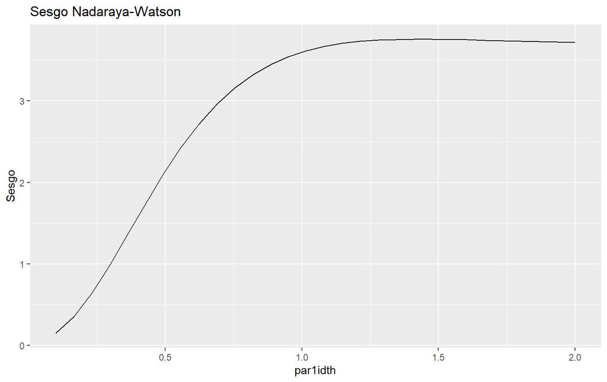

```r
#Nadayara
library(ggplot2)
set.seed(1)
X <- seq(-1,1,length=101)
d <- purrr::map(function(a) X + 4*cos(7*X) + rnorm(101), .x = rep(1,1000))

par1 <- seq(0.1,2,length.out = 30)
list1 <- list()
for (i in 1:length(par1)) {
  list1[[i]]  <- lapply(d, FUN = stats::ksmooth, kernel = "normal", bandwidth = par1[i] , x = X)
}

##xi-0.5
posterior <- which(X== 0.5)
xi11<- d[[76]]

sim1 <- rep(NA, 1000)
sim1_bat <- list()

for ( n in 1:30) {
for ( m in 1:1000) {
  sim1[m] <- list1[[n]][[m]]$y[76]
}
  sim1_bat[[n]]<- sim1
}

#sesgo
d <- purrr::map(function(a) {y = X + 4*cos(7*X) + rnorm(101)
return(data.frame(X,y))},.x = rep(1,1000))

ses1 <-lapply(d, FUN = function(x) x$y)
ses1 <- do.call(cbind.data.frame, ses1)

colnames(ses1)<- 1:1000
xi11 <- as.vector(as.matrix(ses1[76,]))

sesk30 <- rep(NA, 30)
for (k in 1:30) {
   sesk30[k]<- mean(sim1_bat[[k]]-xi11)
}

# MSE

MSEK30 <- rep(NA, 30)
for (k in 1:30) {
  MSEK30[k]<- mean((sim1_bat[[k]]-xi11)^2)
}

#Variancia
vark30 <- rep(NA, 30)
for (k in 1:30) {
  vark30[k]<- var(sim1_bat[[k]])
}

#Sesgo graficado
sesnay <- data.frame(Sesgo = sesk30, par1idth = par1)
ggplot(sesnay, aes(x = par1idth, y = Sesgo)) +
  geom_line() +
  labs(title = "Sesgo Nadaraya-Watson")
```

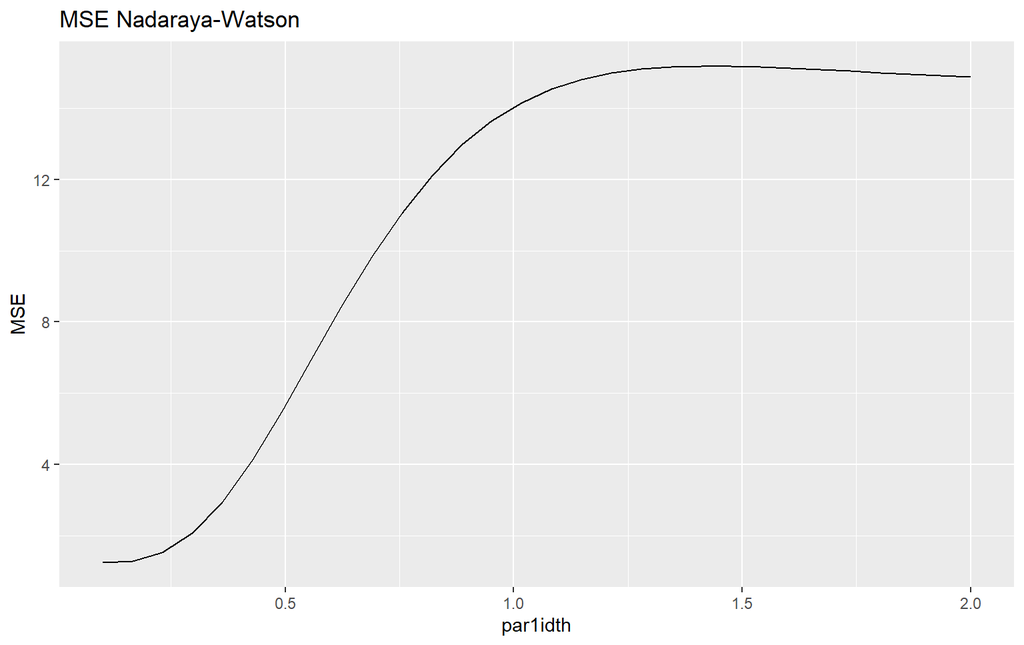

```r
#MSE graficado
msenay <- data.frame(MSE = MSEK30, par1idth = par1)
ggplot(msenay, aes(x = par1idth, y = MSE)) +
  geom_line() +
  labs(title = "MSE Nadaraya-Watson")
```

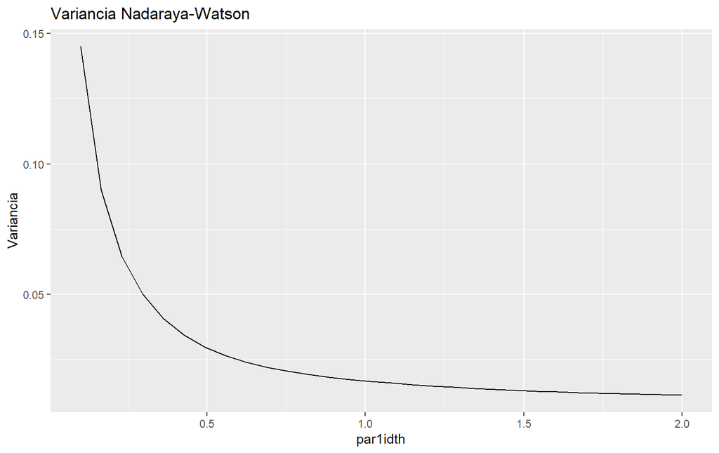

```r
#Variancia graficada
varnay <- data.frame(Variancia = vark30, par1idth = par1)
ggplot(varnay, aes(x = par1idth, y = Variancia)) +
  geom_line() +
  labs(title = "Variancia Nadaraya-Watson")
```

```r
sesnay
```

```
##        Sesgo  par1idth
## 1  0.1495174 0.1000000
## 2  0.3564927 0.1655172
## 3  0.6398305 0.2310345
## 4  0.9812325 0.2965517
## 5  1.3566061 0.3620690
## 6  1.7384509 0.4275862
## 7  2.1029038 0.4931034
## 8  2.4330208 0.5586207
## 9  2.7203923 0.6241379
## 10 2.9630551 0.6896552
## 11 3.1628666 0.7551724
## 12 3.3235625 0.8206897
## 13 3.4498919 0.8862069
## 14 3.5468424 0.9517241
```

[output cut: 16 more lines]

```r
msenay
```

```
##          MSE  par1idth
## 1   1.242901 0.1000000
## 2   1.279740 0.1655172
## 3   1.530673 0.2310345
## 4   2.066155 0.2965517
## 5   2.932278 0.3620690
## 6   4.106372 0.4275862
## 7   5.500830 0.4931034
## 8   6.994060 0.5586207
## 9   8.471761 0.6241379
## 10  9.848310 0.6896552
## 11 11.070171 0.7551724
## 12 12.110670 0.8206897
## 13 12.964753 0.8862069
## 14 13.641678 0.9517241
```

[output cut: 16 more lines]

```r
varnay
```

```
##     Variancia  par1idth
## 1  0.14504015 0.1000000
## 2  0.08980170 0.1655172
## 3  0.06448808 0.2310345
## 4  0.05001339 0.2965517
## 5  0.04069954 0.3620690
## 6  0.03431408 0.4275862
## 7  0.02976220 0.4931034
## 8  0.02642979 0.5586207
## 9  0.02393188 0.6241379
## 10 0.02201247 0.6896552
## 11 0.02049795 0.7551724
## 12 0.01927021 0.8206897
## 13 0.01824957 0.8862069
## 14 0.01738222 0.9517241
```

[output cut: 16 more lines]

#Span #Regresión polinomial

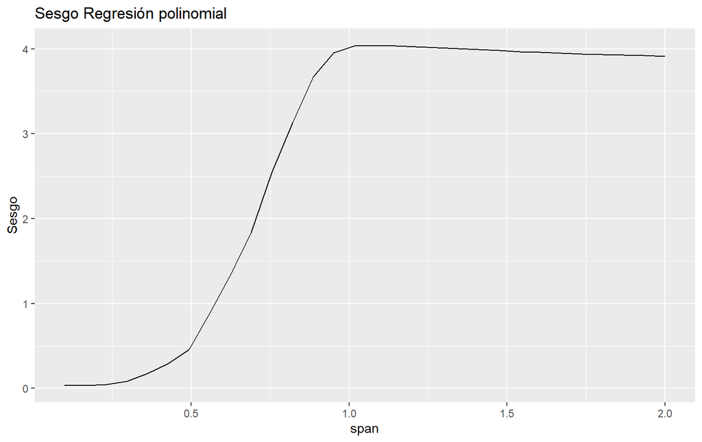

```r
#Span
span1 <- seq(0.1,2,length.out = 30)

list11 <- list()
for (i in 1:length(span1)) {
  list11[[i]]  <- lapply(d, FUN = stats::loess, formula = y ~ X, span = span1[i], degree = 2)
}

sim1 <- rep(NA, 1000)
sim1_bat1 <- list()

for ( n in 1:30) {
  for ( m in 1:1000) {
    sim1[m] <- list11[[n]][[m]]$fitted[76]
  }
  sim1_bat1[[n]]<- sim1
}

#Sesgo
sesp30 <- rep(NA, 30)
for (k in 1:30) {
  sesp30[k]<- mean(sim1_bat1[[k]]-xi11)
}

#MSE
msep30 <- rep(NA, 30)
for (k in 1:30) {
  msep30[k]<- mean((sim1_bat1[[k]]-xi11)^2)
}

#Variancia
varp30 <- rep(NA, 30)
for (k in 1:30) {
  varp30[k]<- var(sim1_bat1[[k]])
}

#Sesgo graficado
sespol <- data.frame(Sesgo = sesp30, span = span1)
ggplot(sespol, aes(x = span, y = Sesgo)) +
  geom_line() +
  labs(title = "Sesgo Regresión polinomial")
```

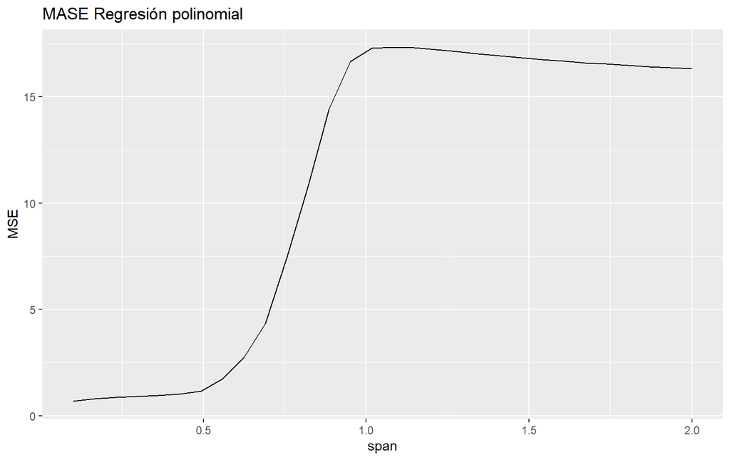

```r
#MSE graficado
msepol <- data.frame(MSE = msep30, span = span1)
ggplot(msepol, aes(x = span, y = MSE)) +
  geom_line() +
  labs(title = "MASE Regresión polinomial")
```

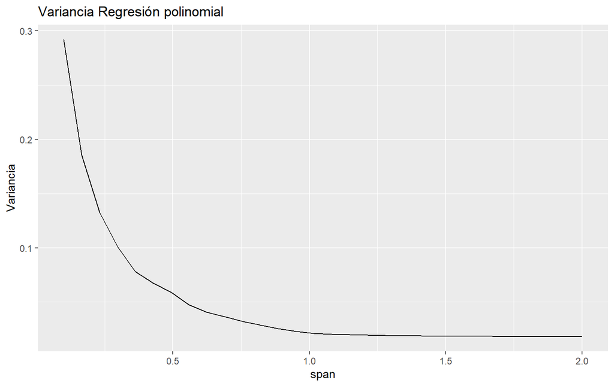

```r
#Variancia graficada
varpol <- data.frame(Variancia = varp30, span = span1)
ggplot(varpol, aes(x = span, y = Variancia)) +
  geom_line() +
  labs(title = "Variancia Regresión polinomial")
```

```r
sespol
```

```
##         Sesgo      span
## 1  0.03359318 0.1000000
## 2  0.03545346 0.1655172
## 3  0.04713820 0.2310345
## 4  0.08178017 0.2965517
## 5  0.17603869 0.3620690
## 6  0.29247373 0.4275862
## 7  0.45646684 0.4931034
## 8  0.88242383 0.5586207
## 9  1.33805786 0.6241379
## 10 1.83271045 0.6896552
## 11 2.53732610 0.7551724
## 12 3.13246813 0.8206897
## 13 3.66681757 0.8862069
## 14 3.95722730 0.9517241
```

[output cut: 16 more lines]

```r
msepol
```

```
##           MSE      span
## 1   0.6868007 0.1000000
## 2   0.8146442 0.1655172
## 3   0.8692989 0.2310345
## 4   0.9059223 0.2965517
## 5   0.9555030 0.3620690
## 6   1.0213012 0.4275862
## 7   1.1534604 0.4931034
## 8   1.7351614 0.5586207
## 9   2.7535816 0.6241379
## 10  4.3275879 0.6896552
## 11  7.4135238 0.7551724
## 12 10.7938446 0.8206897
## 13 14.4342292 0.8862069
## 14 16.6547080 0.9517241
```

[output cut: 16 more lines]

```r
varpol
```

```
##     Variancia      span
## 1  0.29206231 0.1000000
## 2  0.18552531 0.1655172
## 3  0.13274170 0.2310345
## 4  0.10091321 0.2965517
## 5  0.07828269 0.3620690
## 6  0.06753246 0.4275862
## 7  0.05892844 0.4931034
## 8  0.04743333 0.5586207
## 9  0.04052872 0.6241379
## 10 0.03635868 0.6896552
## 11 0.03219258 0.7551724
## 12 0.02891245 0.8206897
## 13 0.02551272 0.8862069
## 14 0.02277503 0.9517241
```

[output cut: 16 more lines]

#lambda #splines de suavizado

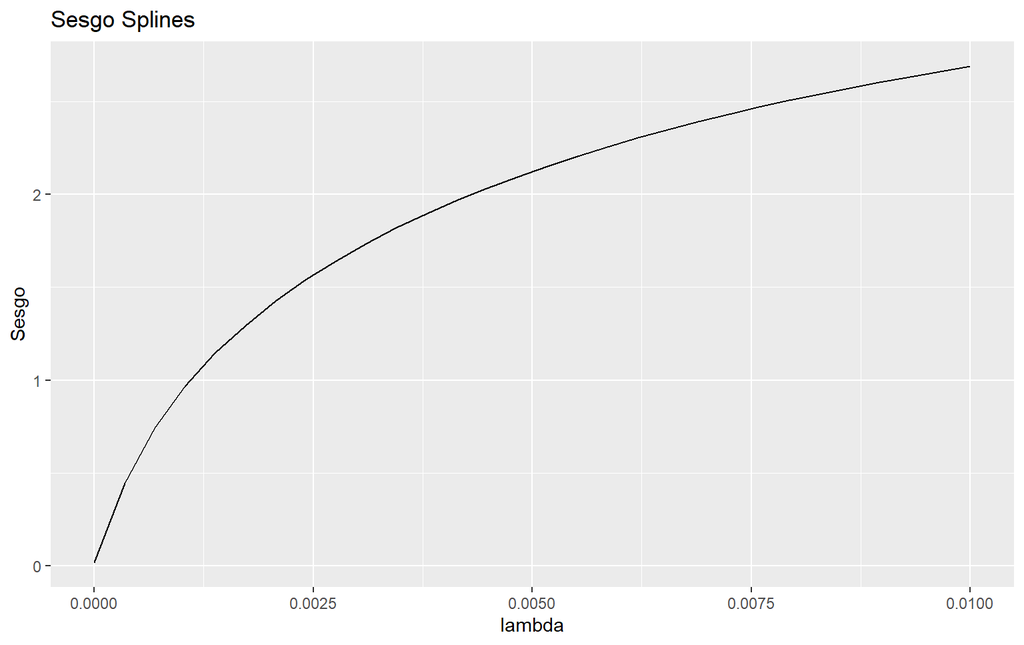

```r
#lambda
d <- purrr::map(function(a) {y = X + 4*cos(7*X) + rnorm(101)
return(data.frame(X,y))},.x = rep(1,1000))
lmbda102 <- (seq(0.000001, 0.01,length.out = 30))
list12 <- list()

for (i in 1:length(lmbda102)) {
  list12[[i]]  <- lapply(d, FUN = stats::smooth.spline, lambda = lmbda102[i])
}

sim1 <- rep(NA, 1000)
sim1_bat2 <- list()

for ( n in 1:30) {
  for ( m in 1:1000) {
    sim1[m] <- list12[[n]][[m]]$y[76]
  }
  sim1_bat2[[n]]<- sim1
}

#Sesgo
sesspl30 <- rep(NA, 30)
for (k in 1:30) {
  sesspl30[k]<- mean(sim1_bat2[[k]]-xi11)
}

#MSE
msespl30 <- rep(NA, 30)
for (k in 1:30) {
  msespl30[k]<- mean((sim1_bat2[[k]]-xi11)^2)
}

#Variancia
varspl30 <- rep(NA, 30)
for (k in 1:30) {
  varspl30[k]<- var(sim1_bat2[[k]])
}

#Sesgo graficado
sesspli30 <- data.frame(Sesgo = sesspl30, lambda = lmbda102)
ggplot(sesspli30, aes(x = lambda, y = Sesgo)) +
  geom_line() +
  labs(title = "Sesgo Splines")
```

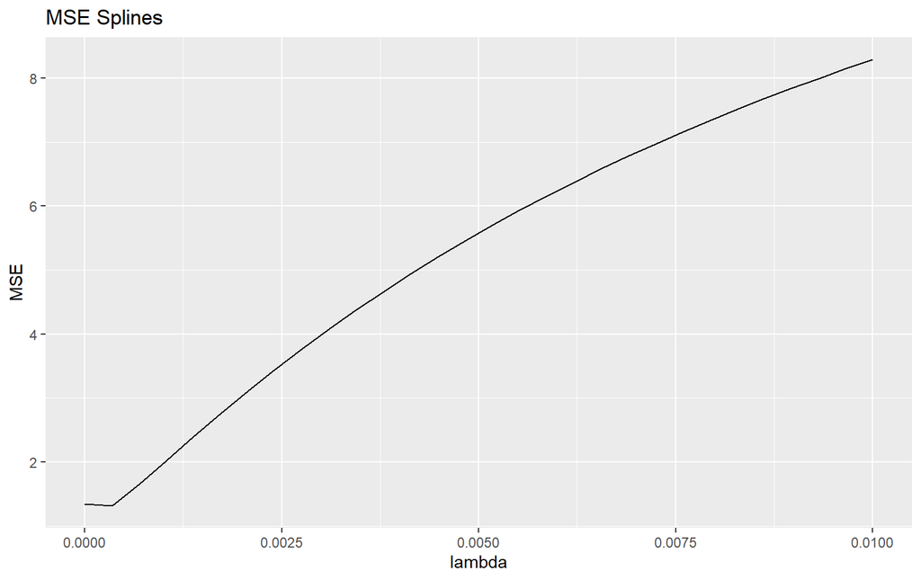

```r
#MSE graficado
msespli30 <- data.frame(MSE = msespl30, lambda = lmbda102)
ggplot(msespli30, aes(x = lambda, y = MSE)) +
  geom_line() +
  labs(title = "MSE Splines")
```

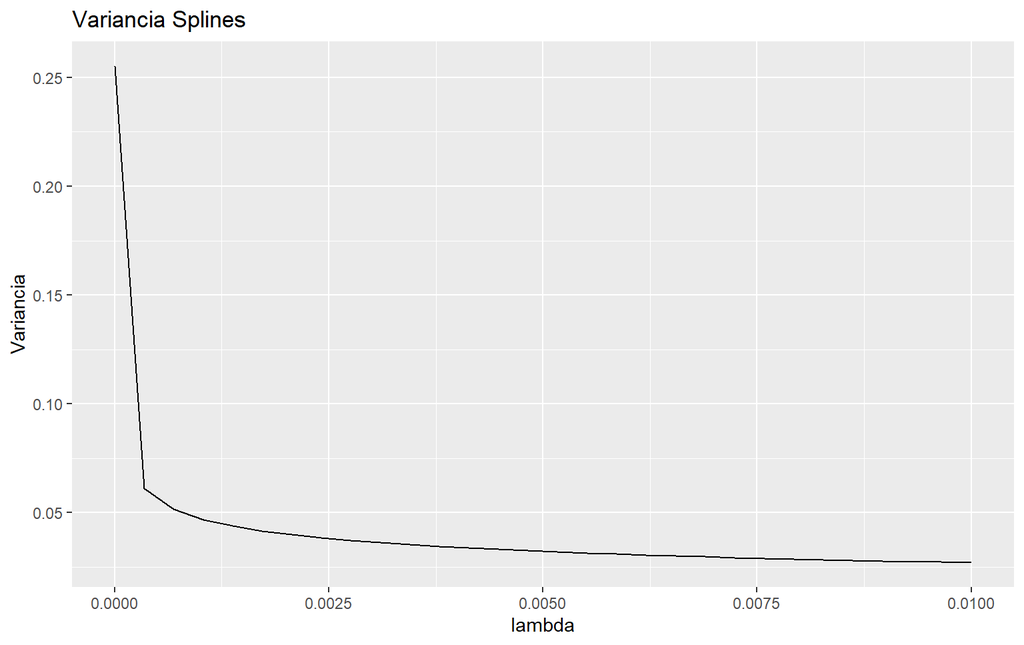

```r
#Variancia graficada
varspl30 <- data.frame(Variancia = varspl30, lambda = lmbda102)
ggplot(varspl30, aes(x = lambda, y = Variancia)) +
  geom_line() +
  labs(title = "Variancia Splines")
```

```r
sesspli30
```

```
##        Sesgo       lambda
## 1  0.0182999 0.0000010000
## 2  0.4470889 0.0003457931
## 3  0.7437510 0.0006905862
## 4  0.9654440 0.0010353793
## 5  1.1440714 0.0013801724
## 6  1.2943767 0.0017249655
## 7  1.4244005 0.0020697586
## 8  1.5390424 0.0024145517
## 9  1.6415313 0.0027593448
## 10 1.7341233 0.0031041379
## 11 1.8184675 0.0034489310
## 12 1.8958126 0.0037937241
## 13 1.9671322 0.0041385172
## 14 2.0332029 0.0044833103
```

[output cut: 16 more lines]

```r
msespli30
```

```
##         MSE       lambda
## 1  1.343874 0.0000010000
## 2  1.313437 0.0003457931
## 3  1.651537 0.0006905862
## 4  2.023027 0.0010353793
## 5  2.395170 0.0013801724
## 6  2.758344 0.0017249655
## 7  3.109281 0.0020697586
## 8  3.446940 0.0024145517
## 9  3.771180 0.0027593448
## 10 4.082256 0.0031041379
## 11 4.380605 0.0034489310
## 12 4.666745 0.0037937241
## 13 4.941229 0.0041385172
## 14 5.204614 0.0044833103
```

[output cut: 16 more lines]

```r
varspl30
```

```
##     Variancia       lambda
## 1  0.25522543 0.0000010000
## 2  0.06101697 0.0003457931
## 3  0.05143341 0.0006905862
## 4  0.04673678 0.0010353793
## 5  0.04373800 0.0013801724
## 6  0.04155728 0.0017249655
## 7  0.03984772 0.0020697586
## 8  0.03844266 0.0024145517
## 9  0.03725073 0.0027593448
## 10 0.03621678 0.0031041379
## 11 0.03530504 0.0034489310
## 12 0.03449092 0.0037937241
## 13 0.03375675 0.0041385172
## 14 0.03308938 0.0044833103
```

[output cut: 16 more lines]

## PREGUNTA 4

Repetir las preguntas `1` y `2` con el diseño aleatorio. De nuevo, utilice un ancho de banda `bandwidth = 0.2` para el estimador de *Nadaraya-Watson* y estime los parámetros `span` y `lambda` (asociados a los estimadores de regresión local polinomial y *splines* de suavizado) tales que los grados de libertad $d\!f$ de los tres métodos coincidan.

```r
set.seed(1)
x2 <- sort(c(0.5, -1 + rbeta(50, 2, 2), rbeta(50, 2, 2)))
```

**Utilice la misma semilla que utilizó en la parte `1` para generar los errores** asociados a las 1000 simulaciones, de manera tal que las innovaciones sean las mismas a lo largo de cada simulación pero los valores $x_i$ sean los únicos que cambien entre el diseño equidistante y el diseño aleatorio.

**PREGUNTA 1**

**A.** Para cada una de las 1000 simulaciones calcule los estimadores de regresión de

- *Nadaraya-Watson* (`ksmooth()`),
- *regresión local polinomial* (`loess()`), y
- *splines de suavizado* (`smooth.spline()`)

para cada $x_i$. Para el estimador de *Nadaraya-Watson* utilice un ancho de banda de 0.2 (`bandwidth = 0.2`). Para la *regresión local polinomial* y los *splines de suavizado* estime los parámetros `span` y `lambda` tales que generen, aproximadamente, los mismos grados de libertad $d\!f$ que el estimador de *Nadaraya-Watson*.

### Pregunta 1

```r
set.seed(1)
mx = function(x2){
  x2+4*cos(7*x2)
}
ei=matrix(rnorm((101*1000),0,1), nrow=101, ncol=1000)


yi = mx(x2)+ei

yv=mx(x2)
```

### Modelo Nayadara-Watson

```r
library(stats)
modelo<-matrix(NA, nrow=101, ncol=1000)
for (i in 1:1000) {
  mod=ksmooth(x=x2, y=yi[,i], bandwidth = 0.2)
  modelo[,i]<-mod$y
}
```

**Para el cálculo de los grados de libertad**

```r
n<-length(yv)
x<-x2
S<-matrix(NA, nrow = n, ncol=n)
colnames(S)<- 1:n
In<-diag(n)
h=0.2

for (j in 1:n){
  krs<-ksmooth(x=x2,
               y=In[,j],
               kernel = "normal",
               bandwidth = h,
               x.points = x)
  S[,j]<-krs$y
}

sum(diag(S))
```

```
## [1] 9.926566
```

### Modelo Regresión local polinomial

Ajustar el span

```r
#Para seleccionar el span. Trabajamos únicamente con una configuración (yi[,1])

h=c(0.1,0.2,0.3,0.4,.5,.6,.7,.8,.9,1)
df<-rep(0, length(h))
for (i in 1:length(h)){
  mod<-loess(yi[,1]~x2, span=h[i])
  df[i]<-mod$enp
}
df
```

```
##  [1] 32.832967 16.525488 10.791121  8.334786  6.301852  5.022019  4.548610
##  [8]  4.123226  3.916376  3.490138
```

El valor más cercano a 9.93 se da entre el span igual a 0.3 y 0.4, estando más cercano a 0.3. Por ende, utilizaremos 0.358

```r
modelo1<-matrix(NA, nrow=101, ncol=1000)
for (i in 1:1000) {
  mod1<-loess(yi[,i]~x2, span = 0.358)
  modelo1[,i]<-mod1$fitted
}
```

### Modelo de splines de suavizado

Se usan los grados de libertad igual a 9.93

```r
modelo2<-matrix(NA, nrow=101, ncol=1000)
for (i in 1:1000) {
  mod2<-smooth.spline(yi[,i]~x2, df=9.93)
  modelo2[,i]<-(predict(mod2, x2)$y)
}
```

### Pregunta B

Para cada punto xi, calcule

1. el sesgo empírico de m(xi) (promedio a lo largo de todas las simulaciones menos el valor verdadero m(x)),

**Modelo Nayadara-Watson**

```r
SE1.MAT<-yv-modelo
SE1<-rep(NA, 101)
for (i in 1:101){
  SE1[i]<-mean(SE1.MAT[i,])
}
```

**Modelo de regresión local polinomial**

```r
SE2.MAT<-yv-modelo1
SE2<-rep(NA, 101)
for (i in 1:101){
  SE2[i]<-mean(SE2.MAT[i,])
}
SE2
```

```
##   [1] -0.6905638196 -0.2705119387  0.6920825695  0.8024382758  0.5924802330
##   [6]  0.5664092890  0.3532560736  0.3187275322  0.2383238576  0.2335874458
##  [11]  0.1573756837  0.1114786015  0.0878312340  0.0139266190 -0.0011983537
##  [16] -0.0053279081 -0.0055196988 -0.0092564553 -0.0110412305 -0.0260238045
##  [21] -0.0275826058 -0.0286766382 -0.0325251837 -0.0416744563 -0.0459227049
##  [26] -0.0354822586 -0.0443205373 -0.0453008467 -0.0448225258 -0.0447229545
##  [31] -0.0424804743 -0.0279455861  0.0018427575  0.0108504247  0.0170304821
##  [36]  0.0232827609  0.0415053332  0.0630853181  0.0836979030  0.0888436132
##  [41]  0.1015339757  0.1353125430  0.1810013134  0.2072439164  0.2237410472
##  [46]  0.3722384897  0.4019474708  0.6996918107  0.8740714883  0.9537433054
##  [51]  0.7319265842  0.5311843373  0.4287977069  0.4201947688  0.3895124691
##  [56]  0.3532439384  0.2808578048  0.2602459863  0.1246889070  0.1009324335
##  [61]  0.0360208569  0.0296267972  0.0118352802 -0.0015977565 -0.0053694594
##  [66] -0.0230148098 -0.0441131447 -0.0451865758 -0.0404833628 -0.0454323430
##  [71] -0.0758124934 -0.0758166546 -0.0660081419 -0.0535361631 -0.0531078189
##  [76] -0.0413566002 -0.0357112134 -0.0306434259 -0.0465322003 -0.0574832031
##  [81] -0.0642642923 -0.0566182213 -0.0276218944 -0.0200832393  0.0005393553
##  [86]  0.0139909871  0.0422624027  0.1116373826  0.1277596084  0.1639737225
##  [91]  0.1881424525  0.2914333016  0.3037797151  0.5291530221  0.5292686060
##  [96]  0.5268046167  0.5195062182  0.3410532504  0.2989910031  0.1138558816
## [101] -1.0055153035
```

**Modelo de splines de suavizado**

```r
yv-modelo2[,1]
```

```
##   [1] -0.53537675 -0.20372268  0.40046164  0.44424267  0.18594590  0.16864885
##   [7]  0.03921110  0.01873230 -0.04499988 -0.04998043 -0.16155030 -0.19568276
##  [13] -0.20508005 -0.24162290 -0.26000806 -0.28409797 -0.28569913 -0.29094892
##  [19] -0.29143981 -0.29060171 -0.29034902 -0.29014803 -0.28927216 -0.28558436
##  [25] -0.26559248 -0.22692146 -0.16583571 -0.15272241 -0.14497192 -0.14427513
##  [31] -0.13563857 -0.11669760 -0.10189349 -0.09873687 -0.09620091 -0.09332494
##  [37] -0.08830812 -0.08585252 -0.08383662 -0.08331183 -0.08181977 -0.07626240
##  [43] -0.06390891 -0.05377889 -0.04621444  0.01452472  0.02583703  0.15314057
##  [49]  0.25203625  0.30894382  0.51585229  0.32978153  0.06664194  0.03546516
##  [55] -0.06468908 -0.14394716 -0.23069193 -0.24715200 -0.34588109 -0.36046414
##  [61] -0.38851294 -0.39019207 -0.39391503 -0.39597544 -0.39647686 -0.39871360
##  [67] -0.39964203 -0.39776100 -0.38343636 -0.35801496 -0.23455814 -0.23445530
##  [73] -0.15983747 -0.13490683 -0.13428073 -0.12049815 -0.11437045 -0.10312861
##  [79] -0.09050595 -0.09105257 -0.10377803 -0.11025895 -0.12287239 -0.12547966
##  [85] -0.13475517 -0.14332754 -0.16069441 -0.16457414 -0.16366887 -0.16053350
##  [91] -0.15740269 -0.13086834 -0.12570019  0.19323955  0.28881444  0.30514830
##  [97]  0.33153314  0.44479563  0.44536750  0.41101360 -0.22850423
```

```r
SE3.MAT<-yv-modelo2
SE3<-rep(NA, 101)
for (i in 1:101){
  SE3[i]<-mean(SE3.MAT[i,])
}
SE3
```

```
##   [1] -0.7309615299 -0.3278920440  0.4943687051  0.5750611637  0.4147763089
##   [6]  0.3982554276  0.2722859615  0.2516808854  0.1854806892  0.1801391999
##  [11]  0.0486903505  0.0009543027 -0.0132397346 -0.0662825554 -0.0917659562
##  [16] -0.1274486964 -0.1305050819 -0.1447850160 -0.1477393938 -0.1604415737
##  [21] -0.1613288353 -0.1619727433 -0.1644036460 -0.1719447782 -0.1907518921
##  [26] -0.1997363305 -0.1867684851 -0.1801753213 -0.1753713831 -0.1749020872
##  [31] -0.1685661945 -0.1507813653 -0.1297878567 -0.1234411488 -0.1172074745
##  [36] -0.1078992149 -0.0771579071 -0.0585389138 -0.0465910131 -0.0439389439
##  [41] -0.0370813902 -0.0163768376  0.0183364122  0.0421940687  0.0586530611
##  [46]  0.1752456321  0.1956945033  0.3995903773  0.5310457609  0.5985235361
##  [51]  0.7116571229  0.5158711975  0.2824344758  0.2569383822  0.1760424237
##  [56]  0.1087947294  0.0312174724  0.0163879573 -0.0745632199 -0.0894767098
##  [61] -0.1251630829 -0.1281885440 -0.1361331477 -0.1416783728 -0.1432184639
##  [66] -0.1517437345 -0.1720590449 -0.1798046939 -0.1958582988 -0.2044652911
##  [71] -0.2035545998 -0.2035412241 -0.1886604547 -0.1802929673 -0.1800414620
##  [76] -0.1736697145 -0.1701300586 -0.1614915184 -0.1364352583 -0.1230340882
##  [81] -0.0885589206 -0.0764548522 -0.0543650209 -0.0498086105 -0.0331430227
##  [86] -0.0161220934  0.0348593147  0.0953557287  0.1039300657  0.1226667299
##  [91]  0.1358035823  0.1982623417  0.2064747893  0.3880932704  0.3835401130
##  [96]  0.3798941290  0.3717671896  0.2208224798  0.1857035056  0.0282721802
## [101] -1.0220332919
```

2. La varianza de m^(xi)

**Modelo Nayadara-Watson**

```r
variancia1<-rep(0, 101)
for (i in 1:101){
  variancia1[i]<-var(modelo[i,])
}
```

**Modelo de regresión local polinomial**

```r
variancia2<-rep(0, 101)
for (i in 1:101){
  variancia2[i]<-var(modelo1[i,])
}
```

**Modelo de splines de suavizado**

```r
variancia3<-rep(0, 101)
for (i in 1:101){
  variancia3[i]<-var(modelo2[i,])
}
```

```r
RE1<-SE1.MAT^2
MSE1<-rep (0, 101)
for (i in 1:101){
MSE1[i]<-(sum(RE1[,i])/101)
}

RE2<-SE2.MAT^2
MSE2<-rep (0, 101)
for (i in 1:101){
MSE2[i]<-(sum(RE2[,i])/101)
}

RE3<-SE3.MAT^2
MSE3<-rep (0, 101)
for (i in 1:101){
MSE3[i]<-(sum(RE3[,i])/101)
}
```

### Pregunta C

Grafique estas tres cantidades contra xi para los estimadores.

**Modelo Nayadara-Watson**

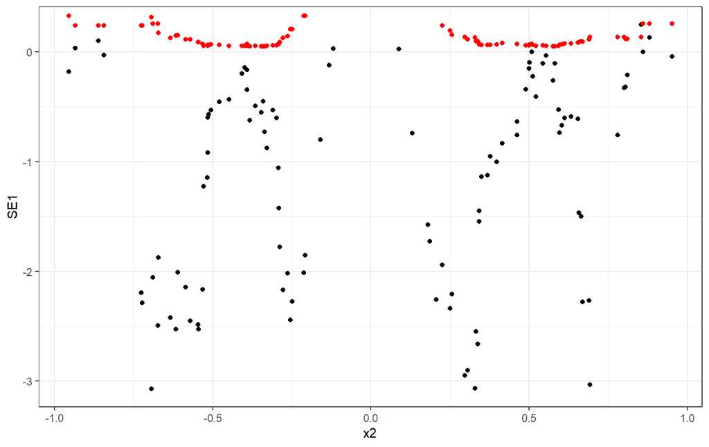

```r
library (ggplot2)
NW<-cbind(variancia1, SE1, MSE1, x2)
NW<-tibble::tibble(NW)

graf1<-ggplot (NW) + geom_point(aes(x=x2, y=SE1))+geom_point(x=x2, y=variancia1, col="red")+geom_point(x=x2, y=MSE1, col="blue")+theme_bw()
graf1
```

**Modelo de regresión local polinomial**

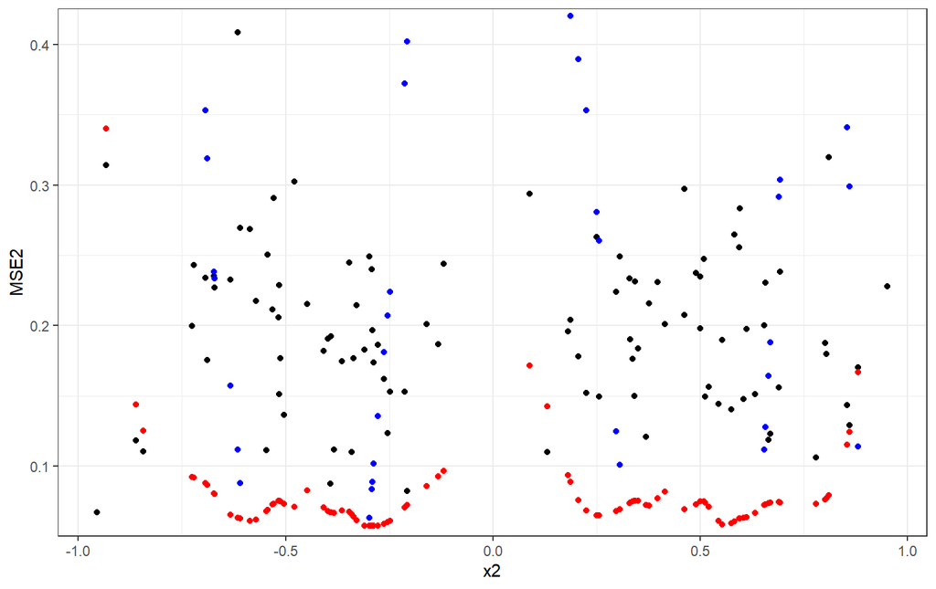

```r
RLP<-cbind(variancia2, SE2, MSE2, x2)
RLP<-tibble::tibble(RLP)

graf2<-ggplot (RLP) + geom_point(aes(x=x2, y=MSE2))+geom_point(x=x2, y=variancia2, col="red")+geom_point(x=x2, y=SE2, col="blue")+theme_bw()
graf2
```

**Modelo de splines de suavizado**

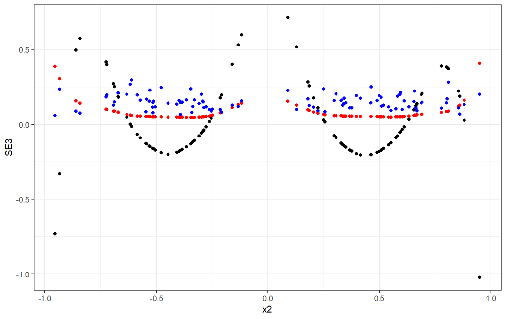

```r
MSS<-cbind(variancia3, SE3, MSE3, x2)
MSS<-tibble::tibble(MSS)

graf1<-ggplot (MSS) + geom_point(aes(x=x2, y=SE3))+geom_point(x=x2, y=variancia3, col="red")+geom_point(x=x2, y=MSE3, col="blue")+theme_bw()
graf1
```

### Pregunta D

¿Cuál es la conexión entre el sesgo y la curvatura $m^{\prime\prime}(x)$?

### Pregunta E

¿Cómo se comporta el sesgo en los bordes?

En los bordes el sesgo crece para la regresión local polinomial y splines suavizados, para el caso de Nadaraya Watson el sesgo pareciera que es menor.

### PREGUNTA 2

**A.** Calcule el correspondiente estimado de error estándar para cada una de las 1000 simulaciones, los 101 $x_i$ y los tres estimadores de regresión estudiados según la fórmula:

$$\hat{\text{se}}\left(\hat{m}(x_i)\right) = \sqrt{ \hat{\mathbb{V}\text{ar}}\left(\hat{m}(x_i)\right)} = \hat{\sigma}_{\epsilon} \sqrt{\left(\mathcal{S} \mathcal{S}^{\intercal} \right)_{ii}}$$

Para estimar *manualmente* el error estándar necesitamos las correspondientes matrices de suavizado (o *hat matrices*) $\mathcal{S}$. Recuerden que las matrices $\mathcal{S}$ dependen únicamente de los puntos de diseño $x_i$ y, por ende, no deben ser calculadas para cada simulación (mas sí para cada método de regresión).

```r
library(tidyverse)
```

```r
# replicando los valores pero en una lista
yi <- vector("list", 1000)

for(i in 1:1000){
  yi[[i]] <-  mx(x2) + rnorm(101, 0, 1)
}

nad_res <- yi %>%
  map(~{ksmooth(x = x2, y = .x, kernel = 'normal', bandwidth = 0.2) %>%
      pluck("y")})

pol_res <- yi %>%
  map(function(y){
      res <- loess(y ~ x2, span = 0.358)
      return(list(
        fitted = res$fitted,
        resid = res$residuals
      ))
  })

# Replico la Matriz S para no tener NA's

n <- length(x2)
x <- x2
S <- matrix(NA, nrow = n, ncol=n)
colnames(S) <- 1:n
In <- diag(n)
h <- 0.2

for (j in 1:n){
  krs<-ksmooth(x=x,
               y=In[,j],
               kernel = "normal",
               bandwidth = h,
               x.points = x)
  S[,j]<-krs$y
}


spl_res <- yi %>%
  map(function(y){
      res <- smooth.spline(x2, y, df = sum(diag(S)))
      return(list(
        fitted = res$y,
        lambda = res$lambda
      ))
  })


# Para KS
se_ks <- vector("list", length(x2))
raiz_S <- sqrt(S%*%t(S))

for(j in 1:1000){
  wi <- nad_res[[j]]
  sigma_2 <- sum((wi - yi[[j]])^2)/(length(wi)-sum(diag(S)))
  se_ks[[j]] <- sqrt(sigma_2)*diag(raiz_S)

}


# Para Loess
se_ls <- vector("list", length(x2))
raiz_S <- sqrt(modelo1%*%t(modelo1))

for(j in 1:1000){
  wi <- pol_res[[j]]$fitted
  sigma_2 <- sum((wi - yi[[j]])^2)/(length(wi)-sum(diag(modelo1)))
  se_ls[[j]] <- sqrt(sigma_2)*diag(raiz_S)

}

# Para Splines
se_sp <- vector("list", length(x2))
raiz_S <- sqrt(modelo2%*%t(modelo2))

for(j in 1:1000){
  wi <- spl_res[[j]]$fitted
  sigma_2 <- sum((wi-yi[[j]])^2)/(length(wi)-sum(diag(modelo2)))
  se_sp[[j]] <- sqrt(sigma_2)*diag(raiz_S)

}
```

**B.** Calcule los intervalos de confianza *locales* (*piecewise*) al 95% para los tres métodos estudiados según

$$I = \hat{m}(x_i) \pm 1.96 \cdot \hat{\text{se}}\left(\hat{m}(x_i)\right)$$

```r
# inserte acá su código

## Para KS

ic_ks <- vector("list", length(x2))
for(j in 1:1000){
  yi <- nad_res[[j]]
  ic_ks[[j]] <- list()
  ic_ks[[j]]$ICI <- yi - 1.96*se_ks[[j]]
  ic_ks[[j]]$ICS <- yi + 1.96*se_ks[[j]]
}

## Para Loess
ic_ls <- vector("list", length(x2))
for(j in 1:1000){
  yi <- pol_res[[j]]$fitted
  ic_ls[[j]] <- list()
  ic_ls[[j]]$ICI <- yi - 1.96*se_ls[[j]]
  ic_ls[[j]]$ICS <- yi + 1.96*se_ls[[j]]
}

## Para Splines

ic_sp <- vector("list", length(x2))
for(j in 1:1000){
  yi <- spl_res[[j]]$fitted
  ic_sp[[j]] <- list()
  ic_sp[[j]]$ICI <- yi - 1.96*se_sp[[j]]
  ic_sp[[j]]$ICS <- yi + 1.96*se_sp[[j]]
}
```

**C.** ¿Qué porcentaje de veces el intervalo de confianza *local* contiene el valor verdadero $m(0.5)$ para cada uno de los métodos estudiados?

En los modelos de regresion polinomial y de splines se obtienen valores dentro de los intervalos de confianza, en otras palabras el 100% de los intervalos de confianza *local* contiene el valor verdadero de $m(0.5)$, para cada uno de estos dos modelos, no así en el caso del modelo de Nadayara Watson.

```r
# inserte acá su código
l_5 <- mx(0.5)
x_pos <- which(x2 == 0.5)

# Para KS

ks_05 <- vector("double", length(x2))
for(j in 1:1000){
  ks_05[j] <- l_5 >= ic_ks[[j]]$ICI[x_pos] & l_5 <= ic_ks[[j]]$ICS[x_pos]
}

porcentaje_ks <- sum(ks_05)/length(ks_05)

# Para Loess

ls_05 <- vector("double", length(x2))
for(j in 1:1000){
  ls_05[j] <- l_5 >= ic_ls[[j]]$ICI[x_pos] & l_5 <= ic_ls[[j]]$ICS[x_pos]
}
porcentaje_ls <- sum(ls_05)/length(ls_05)

# Para Splines
sp_05 <- vector("double", length(x2))
for(j in 1:1000){
  sp_05[j] <- l_5 >= ic_sp[[j]]$ICI[x_pos] & l_5 <= ic_sp[[j]]$ICS[x_pos]
}
porcentaje_sp <- sum(sp_05)/length(sp_05)

porcentaje_ks; porcentaje_ls; porcentaje_sp
```

```
## [1] 0.972
```

```
## [1] 1
```

```
## [1] 1
```

**D.** ¿Qué porcentaje de veces la banda de confianza para **todos los puntos** $x_i$ contiene *simultáneamente* todos los valores verdaderos?

El 100% de la veces la banda de confianza para **todos los puntos** $x_i$ contiene *simultáneamente* todos los valores verdaderos, para los modelos de polinomios y los de splines, no así en el de Nadayara Watson.

```r
# inserte acá su código

# Para KS

ban_ic_ks <- vector("double", length(x2))
for(j in 1:1000){
  ban_ic_ks[j] <- all(yi >= ic_ks[[j]]$ICI & yi <= ic_ks[[j]]$ICS)
}
porcentaje_ban_ks <- sum(ban_ic_ks)/length(ban_ic_ks)

# Para Loess

ban_ic_ls <- vector("double", length(x2))
for(j in 1:1000){
  ban_ic_ls[j] <- all(yi >= ic_ls[[j]]$ICI & yi <= ic_ls[[j]]$ICS)
}
porcentaje_ban_ls <- sum(ban_ic_ls)/length(ban_ic_ls)

# Para Splines

ban_ic_sp <- vector("double", length(x2))
for(j in 1:1000){
  ban_ic_sp[j] <- all(yi >= ic_sp[[j]]$ICI & yi <= ic_sp[[j]]$ICS)
}
porcentaje_ban_sp <- sum(ban_ic_sp)/length(ban_ic_sp)

porcentaje_ban_ks; porcentaje_ban_ls; porcentaje_ban_sp
```

```
## [1] 0
```

```
## [1] 1
```

```
## [1] 1
```